# 資料輸入輸出

曾聖澧

Feb 25, 2019

# *簡單內建檔案操作*

- Windows下路徑(path)必須改用 / 或 \\ ， 或是直接以檔案總管選取檔案可用 file.choose() 。  
  dir(path, pattern) 列出 path 下符合pattern 的檔名。dir()則回報目前工作目錄內容。  
  list.files() 功能同 dir()
- R.home() 回報目前執行的R安裝在哪裡。  
  getwd() 可查詢目前工作路徑，更改路徑使用 setwd(目錄路徑) 。
- file.info(path) 可查詢子目錄/檔案大小、權限、修改與存取日期等。  
  basename(path) 列出path中的檔案名，dirname(path)則列出其上一層的目錄名稱。
- dir.create() 是建立新的資料夾。file.copy, file.rename 功能如同其指令名稱易懂。  
  刪除檔案用unlink(path)。

# *讀入程式檔*

語法：source(程式路徑)

先產生程式碼

```r
writeLines(
c("N <- nrow(trees)",
"with(trees, {
symbols(Height, Volume, circles = Girth/24, inches = FALSE,
        main = 'Trees Girth')",
"Sys.sleep(5)",
"op <- palette(rainbow(N, end = 0.9))",
"symbols(Height, Volume, circles = Girth/16, inches = FALSE, bg = 1:N,
        fg = 'gray30', main = '')",
"palette(op)",
"})"),
con="source-demo.R")
```

看看剛剛的檔案內容

```r
file.show("source-demo.R")
```

執行檔案

```r
source("source-demo.R")
```

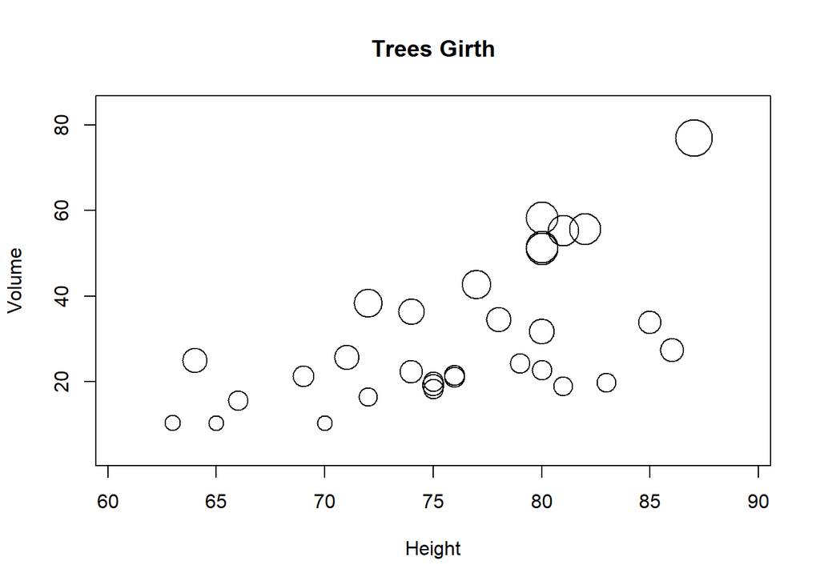

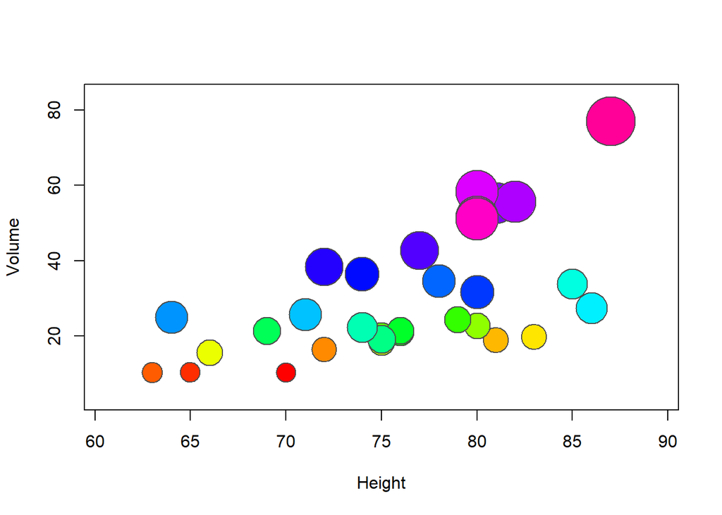

刪除檔案

```r
unlink("source-demo.R")
```

# *讀入不同格式資料檔*

| ID | SCORE | AGE | GENDER |
| --- | --- | --- | --- |
| 1 | 50 | 23 | F |
| 2 | 55 | 22 | M |
| 3 | 40 | 24 | M |
| 4 | 45 | 26 | F |
| 5 | 36 | 21 | M |
| 6 | 48 | 25 | F |

先開啟Excel輸入上表資料，存成example.xls與example.xlsx。  
然後轉換成逗號分隔(examle.csv)，tab分隔(example.txt)的檔案格式。  
另外刪除性別那一欄，另存成逗號分隔的“nogender.csv”。

## scan

看一下內容

```r
file.show("nogender.csv")
```

用 scan 讀入資料

```r
#不含第一行文字
scan("nogender.csv", skip = 1, quiet = TRUE, sep=",")
```

```
##  [1]  1 50 23  2 55 22  3 40 24  4 45 26  5 36 21  6 48 25
```

```r
#只讀檔案中一行資料
scan("nogender.csv", skip = 1, nlines = 1, sep=",")
```

```
## [1]  1 50 23
```

打開剛才自己建立的xls檔案，用滑鼠選取數列複製到剪貼簿。  
以下示範讀取剪貼簿中的複製文字（預設是空白分隔，可由sep選項變更）

```r
scan(file="clipboard",what="",sep="\t")
```

[output not shown]

## readLines

可讀入網路上文章

```r
book=readLines("http://big5.quanben-xiaoshuo.com/n/shuichuan/1.txt",encoding="UTF-8")
View(book)
```

看一下剛剛自己建的資料

```r
file.show("example.csv")
```

逐行讀進文字

```r
readLines("example.csv")
```

```
## [1] "ID,score,age,sex" "1,50,23,F"        "2,55,22,M"
## [4] "3,40,24,M"        "4,45,26,F"        "5,36,21,M"
## [7] "6,48,25,F"
```

## 用Rstudio匯入資料

可參考 https://support.rstudio.com/hc/en-us/articles/218611977-Importing-Data-with-RStudio

重點是把它操作對應的指令記下來，不要太過依賴圖形化使用者介面。

## 以特定字元分隔之資料檔案(CSV,TXT等)

命令列指令是用 read.table, read.delim, read.csv 等， 可參考 https://blog.csdn.net/HHTNAN/article/details/54706885

這些其實都是純文字檔，讀檔時要特別注意是否有欄位名稱（變數名稱），以及分隔的符號是什麼？

以上是對應用Rstudio的 File> Import Dataset > From Text(base)  
也可採用File> Import Dataset > From Text(readr)， 自行比較一下指令，稍有不同。

## EXCEL 檔案

Rstudio 可直接由功能表點選讀入，或用以下指令：

```r
library(readxl)
A=read_xlsx("example.xlsx")
B=read_xls("example.xls")
```

```r
library(ezpickr)
A=pick("example.xlsx")$Sheet1
B=pick("example.xls")
```

## SPSS 檔案

先下載 http://cw.routledge.com/textbooks/9780805861853/spss-data-sets/InagakiLong.sav

Rstudio 可直接由功能表點選讀入，可在命令列查看對應的指令(haven::read_spss)。

## SAS 檔案

先下載 https://github.com/epam/parso/blob/master/src/test/resources/sas7bdat/mixed_data_two.sas7bdat

Rstudio 可直接由功能表點選讀入，可在命令列查看對應的指令(haven::read_sas)。

## JSON

這是一種網路上常見的檔案交換格式  
可參考 https://blog.gtwang.org/r/jsonlite-json-format-parser-generator-tutorial/

## .mat檔

先下載 https://github.com/fsprojects/matprovider/raw/master/data/varTypes.mat

```r
library(R.matlab)
mlst<-readMat("varTypes.mat")
names(mlst)
```

```
## [1] "x"      "y"      "z"      "sample"
```

## .Rdata 二進位檔

先下載 http://www.rdatamining.com/data/termDocMatrix.rdata?attredirects=0&d=1

可由命令列輸入指令讀取，Windows的RGUI可直接拖拉丟進R 的命令列，Rstudio則是從File > Open File…

```r
load("termDocMatrix.Rdata")
```

## 使用R套件中的資料

```r
data(iris)
data(iris,package="datasets")
data(biopsy,package="MASS")
```

第二行與第一行結果相同，是因為 dataset 是預設會搜尋的套件，但第三行不指定MASS會找不到。

# *輸出資料*

## 給人看或給其他程式用

常用有 cat, sink, writeLines, write.table  
可參考 https://www.cnblogs.com/timeisbiggestboss/p/7766115.html

## .mat檔

一次可以不只存一個變數

```r
library(R.matlab)
aa <- matrix(1:27, ncol=3)
bb <- as.matrix(1:10)
cc <- array(1:18, dim=c(2,3,3))
writeMat("Robj.mat", A=aa, B=bb, C=cc)
```

## .Rdata 檔

一次可以不只存一個變數

```r
 Dataset <-matrix(1:10,5,2)
 save(Dataset, file="testdata.Rdata")
 save(Dataset, termDocMatrix, file="testdata2.Rdata")
```

## 壓縮檔

產生一個壓縮檔

```r
bz <- bzfile("df.bz", "w")
write.csv(aa,file=bz,row.names =F)
close(bz)
```

讀入壓縮檔的作法只是write改成read

```r
bz <- bzfile("df.bz", "r")
read.csv(file=bz)
```

```
##   V1 V2 V3
## 1  1 10 19
## 2  2 11 20
## 3  3 12 21
## 4  4 13 22
## 5  5 14 23
## 6  6 15 24
## 7  7 16 25
## 8  8 17 26
## 9  9 18 27
```

```r
close(bz)
```

# *覺得煩嗎？*

光讀寫個檔案都這麼麻煩，要怎麼說服使用者R是資料分析的利器？  
那就試試 rio 吧！如果它認識格式就直接轉換，或者根據你指定的 format轉換。

轉換的三大指令，import/export/convert：

http://finzi.psych.upenn.edu/R/library/rio/html/import.html

http://finzi.psych.upenn.edu/R/library/rio/html/export.html

http://finzi.psych.upenn.edu/R/library/rio/html/convert.html

簡單教學在 https://cran.r-project.org/web/packages/rio/vignettes/rio.html

# *其他*

還有一些特殊的格式或處理較大資料的技巧，請自行參考 https://www.datacamp.com/community/tutorials/importing-data-r-part-two